# Final_commuting

2024-05-07

## Introduction

This document seeks to answer the inference question:

#### What drives commuting decisions?

The goal of this investiagtion therefore is to determine which variables are the strongest predictors of commuting patterns.

This is done in a few ways:

- firstly, by joining the commuting data with point geometries, the spatial variation in some key variables is established.
- Secondly, the variables are then investigated for pairwise and multi-collinearity. This offers important context for when evaluating model results and variable importances.
- Thirdly, to disseminate variable importances for different amounts of commuting, linear models were trained for each ‘journey_count_decile’, so that the most important variables at each level could be compared. Note, given the non-linear and high dimensional structure of the data, linear models were not expected to perform well; they serve only as an indicator of the most influential variables for different commuting levels.
- The variable importances by deciles were then compared to variable importances calculated using a random forest model. A random forest model was expected to perform well with this data for the same reason a linear model would perform poorly: the nonlinear data requires a flexible model and the high dimensionality suits a random forest better than alternative models such as KNN as they can only measure “distance” which would have required the normalisation of all the variables and still would not have returned useful insights on variable importances.
- Following this, a random forest model was tuned for minimal predictive error to reassess variable importances. The variable importances returned from this model with reduced error and improved accuracy are more reliable. The variable importances returned from a poorly performing linear model will be less useful - for example a variable being ‘unimportant’ in a linear might indicate it its influence is non-linear, not that it neccisarily does not influence the outcomes.
- Using these variables, an XGBoost model was trained. This model type trains considerably faster than Random Forest models and also handles high dimensional non linear data. It’s variable importances therefore offer useful validation for the variable importances from the Random Forest model.
- All of these investigations contribute to ‘painting a picture’ of what drives commuting decisions.
- Finally, there is some speculation as how the answers for this question could be more accurate and robust but were made impossible by the computational constraints.

## Workflow

```r
# setting working directory
# setwd("C:/Users/ni20171/OneDrive - University of Bristol/Msc Geographic Data Science & Spatial Analytics/Machine Learning/Final/Commute")
```

```r
# calling required packages
library(tidyverse)      # for dplyr, ggplot2 etc
library(sf)             # for handling spatial featrures
library(caret)          # for training models
library(SpatialML)      # for random forests
library(corrplot)       # for correlation matrix
library(car)            # for VIFs
library(kableExtra)     # for printing results (DO I USE THIS)
library(corrr)
library(polycor)
library(xgboost)
library(GWmodel)
library(spdep)
library(spatialreg)
library(class)
library(patchwork)     # for plotting ggplots in a grid
```

```r
# reading in commuter data
commute_full = read_csv("LAcommute.csv",
                        trim_ws = TRUE, # removing trailing and leading spaces
                        col_select = -(c("...1")), # removing the index
                        col_types = cols(date = col_date(format = "%d/%m/%Y"))) # ensuring dates are handled correctly
```

```r
dim(commute_full)
```

```
## [1] 316519     24
```

```r
# subsetting data to reduce computation
dates = as.Date("2019-09-02") # selcting weekday (Monday) - for representative work week sample

commute <- commute_full %>%
  filter(date %in% dates)

# printing inspection of columns
head(commute)
```

```
## # A tibble: 6 × 24
##   date       area_name_origin area_code_origin area_name_dest     area_code_dest
##   <date>     <chr>            <chr>            <chr>              <chr>
## 1 2019-09-02 Hartlepool       E06000001        Hartlepool         E06000001
## 2 2019-09-02 Hartlepool       E06000001        Stockton-on-Tees   E06000004
## 3 2019-09-02 Hartlepool       E06000001        County Durham      E06000047
## 4 2019-09-02 Middlesbrough    E06000002        Middlesbrough      E06000002
## 5 2019-09-02 Middlesbrough    E06000002        Redcar and Clevel… E06000003
## 6 2019-09-02 Middlesbrough    E06000002        Stockton-on-Tees   E06000004
## # ℹ 19 more variables: journey_score <dbl>, journey_count_decile <dbl>,
## #   distance <dbl>, population_origin <dbl>, population_dest <dbl>,
## #   value_added_hourly_origin <dbl>, median_weekly_pay_origin <chr>,
## #   emp_rate_origin <chr>, travel_time_origin <dbl>, gcse_rate_origin <chr>,
## #   life_satisfaction_origin <chr>, housing_growth_origin <dbl>,
## #   value_added_hourly_dest <dbl>, median_weekly_pay_dest <chr>,
## #   emp_rate_dest <chr>, travel_time_dest <dbl>, gcse_rate_dest <chr>, …
```

```r
# checking dimensions after subsetting
dim(commute)
```

```
## [1] 858  24
```

```r
# reading in supplementary data so that Commuter data may be geolocated
LAD_shapefile = st_read("CTYUA_DEC_2023_UK_BFC.shp")
# transforming polygon geometries to midpoints (saves computation)
centroids = st_centroid(LAD_shapefile)
centroids_sf = st_sf(gemoetry = centroids)

# removing polygon geometries
LAD_shapefile$geometry <- NULL

# binding centroids to LAD_shapefile
LAD_shapefile <- cbind(LAD_shapefile, centroids_sf)

# inspecting LAD_shapefile
head(LAD_shapefile)
```

```
##   CTYUA23CD            CTYUA23NM CTYUA23NMW  BNG_E  BNG_N     LONG     LAT
## 1 E06000001           Hartlepool       <NA> 447160 531474 -1.27018 54.6761
## 2 E06000002        Middlesbrough       <NA> 451141 516887 -1.21099 54.5447
## 3 E06000003 Redcar and Cleveland       <NA> 464361 519597 -1.00608 54.5675
## 4 E06000004     Stockton-on-Tees       <NA> 444940 518179 -1.30664 54.5569
## 5 E06000005           Darlington       <NA> 428029 515648 -1.56835 54.5353
## 6 E06000006               Halton       <NA> 354246 382146 -2.68853 53.3342
##                               GlobalID CTYUA23CD            CTYUA23NM
## 1 40eb08f8-dbd5-47c1-81ae-7ab052c5aad3 E06000001           Hartlepool
## 2 1de046dd-a718-4262-b96e-7989feeb82b7 E06000002        Middlesbrough
## 3 36aded20-0245-4525-aff9-34899fcd7e15 E06000003 Redcar and Cleveland
## 4 9a03146a-07e1-458a-b902-57dbbdca47e3 E06000004     Stockton-on-Tees
## 5 e2a661a2-d6ad-429d-a499-b5a8617a1b90 E06000005           Darlington
## 6 4fb019c9-f0e5-4b5e-bfe3-8f40e9b49a12 E06000006               Halton
##   CTYUA23NMW  BNG_E  BNG_N     LONG     LAT
## 1       <NA> 447160 531474 -1.27018 54.6761
## 2       <NA> 451141 516887 -1.21099 54.5447
## 3       <NA> 464361 519597 -1.00608 54.5675
## 4       <NA> 444940 518179 -1.30664 54.5569
## 5       <NA> 428029 515648 -1.56835 54.5353
## 6       <NA> 354246 382146 -2.68853 53.3342
##                               GlobalID                  geometry
## 1 40eb08f8-dbd5-47c1-81ae-7ab052c5aad3   POINT (447862.7 530737)
## 2 1de046dd-a718-4262-b96e-7989feeb82b7 POINT (450415.4 516581.9)
## 3 36aded20-0245-4525-aff9-34899fcd7e15 POINT (463444.5 517820.3)
## 4 9a03146a-07e1-458a-b902-57dbbdca47e3   POINT (443274 518687.3)
## 5 e2a661a2-d6ad-429d-a499-b5a8617a1b90 POINT (429039.5 517141.7)
## 6 4fb019c9-f0e5-4b5e-bfe3-8f40e9b49a12   POINT (352684.3 383374)
```

```r
# cutting shapefile down
LAD_shapefile_cut <- LAD_shapefile %>%
  select(1, geometry)
# checking it is now only the LAD code and point geometries
head(LAD_shapefile_cut)
```

```
##   CTYUA23CD                  geometry
## 1 E06000001   POINT (447862.7 530737)
## 2 E06000002 POINT (450415.4 516581.9)
## 3 E06000003 POINT (463444.5 517820.3)
## 4 E06000004   POINT (443274 518687.3)
## 5 E06000005 POINT (429039.5 517141.7)
## 6 E06000006   POINT (352684.3 383374)
```

```r
# joining data by common lad codes (doing from origin)
commute_gdf = left_join(commute, LAD_shapefile_cut, by = c("area_code_origin" = "CTYUA23CD"))
commute_gdf = st_as_sf(commute_gdf)

head(commute_gdf)
```

```
## Simple feature collection with 6 features and 24 fields
## Geometry type: POINT
## Dimension:     XY
## Bounding box:  xmin: 447862.7 ymin: 516581.9 xmax: 450415.4 ymax: 530737
## Projected CRS: OSGB36 / British National Grid
## # A tibble: 6 × 25
##   date       area_name_origin area_code_origin area_name_dest     area_code_dest
##   <date>     <chr>            <chr>            <chr>              <chr>
## 1 2019-09-02 Hartlepool       E06000001        Hartlepool         E06000001
## 2 2019-09-02 Hartlepool       E06000001        Stockton-on-Tees   E06000004
## 3 2019-09-02 Hartlepool       E06000001        County Durham      E06000047
## 4 2019-09-02 Middlesbrough    E06000002        Middlesbrough      E06000002
## 5 2019-09-02 Middlesbrough    E06000002        Redcar and Clevel… E06000003
## 6 2019-09-02 Middlesbrough    E06000002        Stockton-on-Tees   E06000004
## # ℹ 20 more variables: journey_score <dbl>, journey_count_decile <dbl>,
## #   distance <dbl>, population_origin <dbl>, population_dest <dbl>,
## #   value_added_hourly_origin <dbl>, median_weekly_pay_origin <chr>,
## #   emp_rate_origin <chr>, travel_time_origin <dbl>, gcse_rate_origin <chr>,
## #   life_satisfaction_origin <chr>, housing_growth_origin <dbl>,
## #   value_added_hourly_dest <dbl>, median_weekly_pay_dest <chr>,
## #   emp_rate_dest <chr>, travel_time_dest <dbl>, gcse_rate_dest <chr>, …
```

```r
# checking geometry
head(commute_gdf$geometry)
```

```
## Geometry set for 6 features
## Geometry type: POINT
## Dimension:     XY
## Bounding box:  xmin: 447862.7 ymin: 516581.9 xmax: 450415.4 ymax: 530737
## Projected CRS: OSGB36 / British National Grid
## First 5 geometries:
```

```
## POINT (447862.7 530737)
## POINT (447862.7 530737)
## POINT (447862.7 530737)
```

```
## POINT (450415.4 516581.9)
## POINT (450415.4 516581.9)
```

```r
# checking every LAD has a unique geometry
unique(commute$area_code_origin) %>%
  length() == unique(commute_gdf$geometry) %>%
  length()
```

```
## [1] TRUE
```

```r
# add one hot encoded column of if commuting to same place
# commute_gdf <- commute_gdf %>%
#   mutate(is_local_commute = ifelse(distance == 0, 1, 0))

# not making an is_local_commute variable because it would be perfectly collinear with distance
```

```r
# ensuring all columns that should be numeric are treated as such
commute_gdf$gcse_rate_origin <- as.numeric(commute_gdf$gcse_rate_origin)
commute_gdf$gcse_rate_dest <- as.numeric(commute_gdf$gcse_rate_dest)
commute_gdf$life_satisfaction_origin<- as.numeric(commute_gdf$life_satisfaction_origin)
commute_gdf$life_satisfaction_dest<- as.numeric(commute_gdf$life_satisfaction_dest)
commute_gdf$emp_rate_origin<- as.numeric(commute_gdf$emp_rate_origin)
commute_gdf$emp_rate_dest<- as.numeric(commute_gdf$emp_rate_dest)

# removing NAs introduced by coercion
dim(commute_gdf)
```

```
## [1] 858  25
```

```r
commute_gdf <- commute_gdf %>% drop_na()
dim(commute_gdf) # checking how many NAs removed
```

```
## [1] 810  25
```

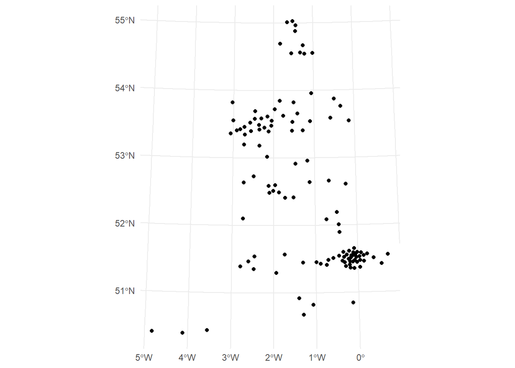

```r
# visualising geometries

ggplot() +
  geom_sf(data = commute_gdf)+
  theme_minimal()
```

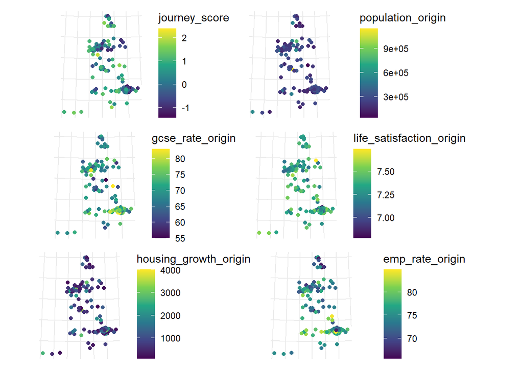

```r
# plotting spatial variation in a few key variables

plot1 <- ggplot() +
  geom_sf(data = commute_gdf, aes(color = journey_score)) +
  scale_color_viridis_c() +
  theme_minimal()+
   labs(x = NULL, y = NULL)+ # removing axes to make the grid neater
  theme(axis.text.x = element_blank(),
        axis.text.y = element_blank(),
        axis.ticks = element_blank())

plot2 <- ggplot() +
  geom_sf(data = commute_gdf, aes(color = population_origin)) +
  scale_color_viridis_c() +
  theme_minimal()+
   labs(x = NULL, y = NULL)+
  theme(axis.text.x = element_blank(),
        axis.text.y = element_blank(),
        axis.ticks = element_blank())

plot3 <- ggplot() +
  geom_sf(data = commute_gdf, aes(color = gcse_rate_origin)) +
  scale_color_viridis_c() +
  theme_minimal()+
   labs(x = NULL, y = NULL)+
  theme(axis.text.x = element_blank(),
        axis.text.y = element_blank(),
        axis.ticks = element_blank())

plot4 <- ggplot() +
  geom_sf(data = commute_gdf, aes(color = life_satisfaction_origin)) +
  scale_color_viridis_c() +
  theme_minimal()+
   labs(x = NULL, y = NULL)+
  theme(axis.text.x = element_blank(),
        axis.text.y = element_blank(),
        axis.ticks = element_blank())

plot5 <- ggplot() +
  geom_sf(data = commute_gdf, aes(color = housing_growth_origin)) +
  scale_color_viridis_c() +
  theme_minimal()+
   labs(x = NULL, y = NULL)+
  theme(axis.text.x = element_blank(),
        axis.text.y = element_blank(),
        axis.ticks = element_blank())

plot6 <- ggplot() +
  geom_sf(data = commute_gdf, aes(color = emp_rate_origin)) +
  scale_color_viridis_c() +
  theme_minimal()+
   labs(x = NULL, y = NULL)+
  theme(axis.text.x = element_blank(),
        axis.text.y = element_blank(),
        axis.ticks = element_blank())

# storing plots in a grid
combined_plot <- (plot1 | plot2) / (plot3 | plot4) / (plot5 | plot6)


print(combined_plot)
```

All of the displayed variables clearly differ spatially.

- journey_score shows an interesting patter where points further away from others appear to have higher journey scores - this could be because these areas have fewer local neighbours and therefore the people there have fewer accessible commuting options.
- population origin should be approximately equal since the LADs are meant to be represenative of population size.
- gcse_rate_origin shows a complicated spatial pattern. This score is often used as part of deprivation indicies and therefore could be a proxy for LAD affluence.
- life_satisfaction_origin also shows a complicated spatial pattern. The lowest scores appear to be in the centre of urban areas however this could be closely tied to age demographics. Fore example, those of retirment age or those with financial stability are likely to have higher life satisfcation than young people with financial instability.
- housing_growth_origin appears to have a similar pattern to population_origin. A parwise correlation measure may confirm this.
- employment_rate has an interesting spatial pattern where there appears to be an approximate north south divide, where the north has higher rates of unemployment. This could be a consequence, among other things, of people moving from the north to London for higher salaries. This is speculative, and the answering of such a question is beyond the cope of this investigation.

```r
# storing as predictors and response for creation of new df
predictors = commute_gdf[, c("area_code_dest", "distance", "population_origin", "population_dest", "value_added_hourly_origin", "median_weekly_pay_origin", "emp_rate_origin", "travel_time_origin", "gcse_rate_origin", "life_satisfaction_origin", "housing_growth_origin", "value_added_hourly_dest", "median_weekly_pay_dest", "emp_rate_dest", "travel_time_dest", "gcse_rate_dest", "life_satisfaction_dest", "housing_growth_dest")]
response = commute_gdf$journey_score


# grf() requires standard dataframe (not spatial)
grf_dat <- as.data.frame(predictors)
grf_dat$journey_score <- response
grf_dat$geometry <- NULL  # removing geometry column

# adding seperate x and y columns for use in grf model
grf_dat$latitude <- st_coordinates(commute_gdf$geometry)[, "Y"]
grf_dat$longitude <- st_coordinates(commute_gdf$geometry)[, "X"]
```

```r
# checking how many NAs per column
colSums(is.na(commute_gdf))
```

```
##                      date          area_name_origin          area_code_origin
##                         0                         0                         0
##            area_name_dest            area_code_dest             journey_score
##                         0                         0                         0
##      journey_count_decile                  distance         population_origin
##                         0                         0                         0
##           population_dest value_added_hourly_origin  median_weekly_pay_origin
##                         0                         0                         0
##           emp_rate_origin        travel_time_origin          gcse_rate_origin
##                         0                         0                         0
##  life_satisfaction_origin     housing_growth_origin   value_added_hourly_dest
##                         0                         0                         0
##    median_weekly_pay_dest             emp_rate_dest          travel_time_dest
##                         0                         0                         0
##            gcse_rate_dest    life_satisfaction_dest       housing_growth_dest
##                         0                         0                         0
##                  geometry
##                         0
```

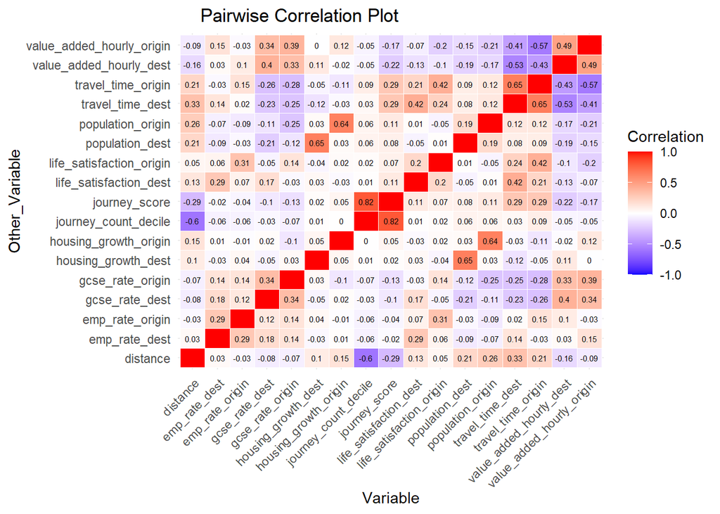

```r
# checking pairwise correlation

# selecting only numeric columns
numeric_cols <- names(select_if(commute_gdf, is.numeric)) %>%
   .[. != "geometry"] %>%
   .[. != "date"] # omitting date because only looking at one day


# removing geometry column
commute_gdf_numeric <- as.data.frame(commute_gdf[, numeric_cols]) %>%
  select(-geometry)

# calculating correlation matrix using caret package
correlation_matrix <- as.data.frame(cor(commute_gdf_numeric, use = "pairwise.complete.obs"))

correlation_df <- correlation_matrix %>%
  as.data.frame() %>%
  rownames_to_column("Variable") %>%
  pivot_longer(-Variable, names_to = "Other_Variable", values_to = "Correlation")

ggplot(correlation_df, aes(x = Variable, y = Other_Variable, fill = Correlation)) +
  geom_tile(color = "white") +
  geom_text(aes(label = ifelse(Variable == Other_Variable, "", round(Correlation, 2))),
            color = "black",# only showing once
            size = 2) + # changing the size of the numers on the plot
  scale_fill_gradient2(low = "blue", high = "red", mid = "white",
                       midpoint = 0,
                       limit = c(-1, 1),
                       name = "Correlation") +
  theme_minimal() +
  labs(title = "Pairwise Correlation Plot") +
  theme(axis.text.x = element_text(angle = 45, hjust = 1),
        plot.title = element_text(hjust = 0.1))
```

Interestingly, population_origin and housing_growth_origin show pairwise correlation (0.64) which would explain the spatial variance detected earlier in population_origin. - These areas have seen greater (or worse) popluation growth since the LAD boundaries were set than is average. Note, correlation is not equivalent to causation however this seems a likely explanation. (the same is true with population_dest and housing_growth_dest).

travel_time_origin and travel_time_destination do have positive pairwise correlation (0.65) although this is actually lower than I would have expected. These two variables seem intrinsically tied together so for them to only have a 0.65 pairwise correlation seems unusual. Future studies might look at why this is and whether travel time discrepancies in the time of day for travel can have such a big impact or if there is another explanation or even if there is an error in the data.

distance was negatively correlated (-0.6) with journey_count_decile. Indicating that for further distances, less people make the journey which is expected. I might have expected this correlation to be even higher at least for middle and further journeys.

Surprisingly, travel_time_origin and travel_time_dest are not strongly correlated with distance (0.21, 0.33 respectively). This could be because distance has been done with euclidean distance however if this were the case we would expect travel time to be more important than distance in the modelling.

```r
# selecting variables to include
all_vars <- names(commute_gdf_numeric)

# excluding unwanted variables
excluded_vars <- c("journey_score",
                   "...1",
                   "journey_count_decile",
                   "area_name_origin",
                   "area_code_origin",
                   "area_name_dest",
                   "area_code_dest",
                   "geometry",
                   "is_local_commute"
                   )
vars_to_include <- all_vars[!all_vars %in% excluded_vars]

# checking how many variables
length(vars_to_include)
```

```
## [1] 15
```

```r
# writing forumla as string
formula_string <- paste("journey_score~", paste(vars_to_include, collapse = " + "))

# Converting to formula
formula <- as.formula(formula_string)
```

```r
# running seperate linear models by journey_count_decile (highly correlated with journey_score (0.82))
model_results <- commute_gdf_numeric %>%
  group_by(journey_count_decile) %>%
  nest() %>%
  mutate(
    lm_model = map(data, ~ lm(formula, data = .)),
    lm_summary = map(lm_model, summary),
    vif_values = map(lm_model, ~ vif(.))
  )

# Getting variable importances
var_importances <- model_results %>%
  mutate(
    var_importance = map(lm_model, ~ varImp(.)),  # Ensure varImp is from the correct package
    var_importance_summary = map(var_importance, ~ as.data.frame(.) %>%
                                   rownames_to_column() %>%
                                   arrange(desc(Overall)) %>%
                                   select(variable = rowname, importance = Overall))
  )

# Getting VIFs
vif_results <- var_importances %>%
  mutate(
    vif = map(lm_model, ~ vif(.))
  )

# putting into a data frame for printing
vif_df <- bind_rows(lapply(vif_results$vif, as.data.frame), .id = "Model_Number")
names(vif_df) <- c("variable", "importance")
```

```r
# printing kable for vif
kable(
  vif_df
) %>%
  kable_styling(full_width = FALSE)
```

|  | variable | importance |
| --- | --- | --- |
| distance…1 | 1 | 2.738663 |
| population_origin…2 | 1 | 3.493627 |
| population_dest…3 | 1 | 3.339122 |
| value_added_hourly_origin…4 | 1 | 2.161788 |
| emp_rate_origin…5 | 1 | 1.434773 |
| travel_time_origin…6 | 1 | 3.310240 |
| gcse_rate_origin…7 | 1 | 1.867145 |
| life_satisfaction_origin…8 | 1 | 1.737704 |
| housing_growth_origin…9 | 1 | 2.168899 |
| value_added_hourly_dest…10 | 1 | 1.960125 |
| emp_rate_dest…11 | 1 | 1.353773 |
| travel_time_dest…12 | 1 | 3.382327 |
| gcse_rate_dest…13 | 1 | 1.738440 |
| life_satisfaction_dest…14 | 1 | 1.679351 |
| housing_growth_dest…15 | 1 | 2.665071 |
| distance…16 | 2 | 2.436526 |
| population_origin…17 | 2 | 2.936612 |
| population_dest…18 | 2 | 2.905608 |
| value_added_hourly_origin…19 | 2 | 1.751424 |
| emp_rate_origin…20 | 2 | 1.298533 |
| travel_time_origin…21 | 2 | 3.123252 |
| gcse_rate_origin…22 | 2 | 1.460709 |
| life_satisfaction_origin…23 | 2 | 1.699850 |
| housing_growth_origin…24 | 2 | 2.332926 |
| value_added_hourly_dest…25 | 2 | 2.043633 |
| emp_rate_dest…26 | 2 | 1.516505 |
| travel_time_dest…27 | 2 | 2.901975 |
| gcse_rate_dest…28 | 2 | 1.808071 |
| life_satisfaction_dest…29 | 2 | 2.140810 |
| housing_growth_dest…30 | 2 | 2.778798 |

[output cut: 120 more lines]

```r
# looking at var_importances

combined_var_importance <- bind_rows(var_importances$var_importance_summary, .id = "model_number")

# Print the combined data frame
print(combined_var_importance)
```

```
##     model_number                  variable importance
## 1              1                  distance 4.71711871
## 2              1         population_origin 2.85557064
## 3              1 value_added_hourly_origin 2.11877213
## 4              1             emp_rate_dest 2.11214348
## 5              1    life_satisfaction_dest 1.81976439
## 6              1     housing_growth_origin 1.78278908
## 7              1   value_added_hourly_dest 1.56077130
## 8              1        travel_time_origin 1.54610817
## 9              1           emp_rate_origin 1.36674500
## 10             1  life_satisfaction_origin 1.11953312
## 11             1          gcse_rate_origin 1.05562870
## 12             1          travel_time_dest 0.79274101
## 13             1           population_dest 0.66493846
## 14             1       housing_growth_dest 0.52216425
```

[output cut: 136 more lines]

Clearly there are significant differences in variable importances depending on the journey_count_decile. Most important feature in the linear model for decile:

- 1 distance
- 2 distance
- 3 value_added_hourly_dest
- 4 life_satisfaction_origin
- 5 distance
- 6 distance
- 7 population_origin
- 8 distance
- 9 gcse_rate_origin
- 10 distance

Interestingly, distance is not the most important variable here for all deciles (only 1,2,5,6,8,10). I would have expected it to be the most important for all deciles, or at least all the higher deciles but this was not the case. Also of ionterest is that the other most important variables are not the same. For example, if it were always distance or value_added_hourly_dest then I might say these were the two most important variables but as it stands the model results indicate the most important variables (other than distance) are highly dependent on which decile ofjourney count is being modelled.

```r
# checking general variable importance with rf model
set.seed(123)

varimp_rf <- train(
  journey_score  ~
      area_code_dest +
      distance +
      population_origin +
      population_dest +
      value_added_hourly_origin +
      median_weekly_pay_origin +
      emp_rate_origin +
      travel_time_origin +
      gcse_rate_origin +
      life_satisfaction_origin +
      housing_growth_origin +
      value_added_hourly_dest +
      median_weekly_pay_dest +
      emp_rate_dest +
      travel_time_dest +
      gcse_rate_dest +
      life_satisfaction_dest +
      housing_growth_dest,
      data = grf_dat,
      method = "rf",
      trControl = trainControl(method = "cv", number = 5), # cross validation method
      tuneGrid = data.frame(mtry = 3),
      ntree = 100 # reducing number of trees to make faster
      )
# printing variable importances
varImp(varimp_rf)
```

```
## rf variable importance
##
##   only 20 most important variables shown (out of 351)
##
##                               Overall
## distance                      100.000
## travel_time_origin             57.885
## travel_time_dest               37.027
## value_added_hourly_dest        33.413
## value_added_hourly_origin      21.900
## population_dest                14.573
## population_origin              14.214
## gcse_rate_origin               14.007
## life_satisfaction_origin       13.232
## life_satisfaction_dest         12.674
## gcse_rate_dest                 11.989
## emp_rate_origin                11.088
## housing_growth_origin          10.222
## emp_rate_dest                   9.301
## housing_growth_dest             7.984
## area_code_destE09000028         5.237
## median_weekly_pay_dest631.9     5.215
## median_weekly_pay_origin714.5   5.156
## area_code_destE06000051         4.641
## median_weekly_pay_origin767     4.504
```

```r
# checking results of varimp_rf
varimp_rf$finalModel
```

```
##
## Call:
##  randomForest(x = x, y = y, ntree = 100, mtry = param$mtry)
##                Type of random forest: regression
##                      Number of trees: 100
## No. of variables tried at each split: 3
##
##           Mean of squared residuals: 0.4892825
##                     % Var explained: 12.14
```

```r
# making linear model to look for multicollinearity (using just variables with overall importance score>9 from rf model)

# distance  100.000000
# travel_time_origin    57.885306
# travel_time_dest  37.027402
# value_added_hourly_dest   33.413440
# value_added_hourly_origin 21.899884
# population_dest   14.572926
# population_origin 14.213847
# gcse_rate_origin  14.007413
# life_satisfaction_origin  13.231950
# life_satisfaction_dest    12.674379
# gcse_rate_dest    11.989494
# emp_rate_origin   11.088392
# housing_growth_origin 10.221765
# emp_rate_dest 9.301274


lin_mod1 = lm(journey_score  ~
      # area_code_dest +
       distance +
       population_origin +
       population_dest +
       value_added_hourly_origin +
      # median_weekly_pay_origin +
       emp_rate_origin +
       travel_time_origin +
       gcse_rate_origin +
       life_satisfaction_origin +
       housing_growth_origin +
       value_added_hourly_dest +
      # median_weekly_pay_dest +
       emp_rate_dest +
       travel_time_dest +
       gcse_rate_dest +
       life_satisfaction_dest,
       #housing_growth_dest,
      data = grf_dat)

# looking for variables with perfect multicollinearity (no perfect pairwise collinearity was found)
aliased <- alias(lin_mod1)$Complete
print(aliased)
```

```r
# now there are no aliased variables (there were with all the variables)
```

```r
# checking VIFs
VIFs <- vif(lin_mod1)
print(VIFs)
```

```
##                  distance         population_origin           population_dest
##                  1.240688                  2.212263                  1.141663
## value_added_hourly_origin           emp_rate_origin        travel_time_origin
##                  2.019541                  1.285461                  2.627706
##          gcse_rate_origin  life_satisfaction_origin     housing_growth_origin
##                  1.458692                  1.518363                  2.075280
##   value_added_hourly_dest             emp_rate_dest          travel_time_dest
##                  1.772223                  1.283278                  2.617791
##            gcse_rate_dest    life_satisfaction_dest
##                  1.440050                  1.448651
```

Travel time is expected to be closely related to distance - I want to keep it in as for urban areas (London especially) where transport options are greater than just driving I predict it will be more important if these can be spatially weighted.

```r
# setting training controls

train_control <- trainControl(
  method = "boot",          # bootstrapping
  number = 10,             # number of resamples
  allowParallel = TRUE
)

# setting train controls
nested_train_control <- trainControl(
  method = "cv",          # using cross validation
  number = 5,             # number of folds
  allowParallel = TRUE
)
```

```r
# setting training formula

all_vars <- names(commute_gdf_numeric)

excluded_vars <- c("journey_score", "journey_count_decile", "is_local_commute")

vars_to_include <- all_vars[!all_vars %in% excluded_vars]
length(vars_to_include)
```

```
## [1] 15
```

```r
# writing forumla as string
formula_string <- paste("journey_score~", paste(vars_to_include, collapse = " + "))

# Converting to formula
formula <- as.formula(formula_string)
```

```r
# training random forest model

set.seed(123)

rf_model <- train(
    formula,
  data = commute_gdf_numeric,
  method = "rf",            # Random forest
  metric = "RMSE",          # Optimising for RMSE (root mean squared error)
  trControl = train_control, # Training control
  search_control = nested_train_control, # nested cross validation control
  allowParallel = TRUE
)

rf_model$finalModel
```

```
##
## Call:
##  randomForest(x = x, y = y, mtry = param$mtry, search_control = ..1,      allowParallel = TRUE)
##                Type of random forest: regression
##                      Number of trees: 500
## No. of variables tried at each split: 15
##
##           Mean of squared residuals: 0.3475332
##                     % Var explained: 37.6
```

```r
# checking variable importances
varImp(rf_model)
```

```
## rf variable importance
##
##                            Overall
## distance                  100.0000
## travel_time_dest           18.7602
## travel_time_origin          9.7401
## population_dest             6.1107
## population_origin           4.7063
## emp_rate_dest               4.6829
## housing_growth_origin       4.3943
## value_added_hourly_dest     4.3501
## value_added_hourly_origin   3.1330
## gcse_rate_dest              3.0979
## housing_growth_dest         2.2151
## emp_rate_origin             1.8792
## gcse_rate_origin            0.9591
## life_satisfaction_origin    0.7763
## life_satisfaction_dest      0.0000
```

```r
# retraining with variables with importance >1
excluded_vars <- c("journey_score", "journey_count_decile", "is_local_commute", "life_satisfaction_dest", "life_satisfaction_origin", "gcse_rate_origin")

vars_to_include <- all_vars[!all_vars %in% excluded_vars]
length(vars_to_include)
```

```
## [1] 12
```

```r
# writing forumla as string
formula_string <- paste("journey_score~", paste(vars_to_include, collapse = " + "))

# Converting to formula
formula <- as.formula(formula_string)


set.seed(123)

rf_model1 <- train(
    formula,
  data = commute_gdf_numeric,
  method = "rf",            # Random forest
  metric = "RMSE",          # Optimising for RMSE (root mean squared error)
  trControl = train_control, # Training control
  search_control = nested_train_control, # nested cross validation control
  allowParallel = TRUE
)

rf_model1$finalModel
```

```
##
## Call:
##  randomForest(x = x, y = y, mtry = param$mtry, search_control = ..1,      allowParallel = TRUE)
##                Type of random forest: regression
##                      Number of trees: 500
## No. of variables tried at each split: 12
##
##           Mean of squared residuals: 0.3436341
##                     % Var explained: 38.3
```

```r
# mse has not significnatly improved
```

```r
# checking variable importances
varImp(rf_model1)
```

```
## rf variable importance
##
##                            Overall
## distance                  100.0000
## travel_time_dest           16.8148
## travel_time_origin          9.1665
## population_origin           4.1362
## population_dest             3.6699
## housing_growth_origin       3.5702
## emp_rate_dest               2.3700
## value_added_hourly_origin   2.2975
## value_added_hourly_dest     1.3472
## gcse_rate_dest              1.1367
## emp_rate_origin             0.7115
## housing_growth_dest         0.0000
```

Random Forest Results MSE: 0.3436341 R2: 0.383

Distance is by far the most important variable. After this travel_time_dest and travel_time_origin are 4 and 2 times larger than the next most important variable (population_origin) respectively.

```r
# Training an XGBoost model to compare variable importances

set.seed(123)

XGB_model <- train(
    formula,
  data = commute_gdf_numeric,
  method = "xgbTree",            # XG Boost
  metric = "RMSE",          # Optimising for RMSE (root mean squared error)
  trControl = train_control, # Training control
  #search_control = nested_train_control, # doesn't accept nested cross validation control
  verbose = FALSE,
  verbosity = 0
)
```

```r
# printing results for model with lowest error
finalXGB = XGB_model$results %>%
  filter(RMSE == min(RMSE))
finalXGB
```

```
##   eta max_depth gamma colsample_bytree min_child_weight subsample nrounds
## 1 0.3         1     0              0.6                1      0.75      50
##        RMSE  Rsquared       MAE     RMSESD RsquaredSD      MAESD
## 1 0.6098428 0.3402426 0.4729247 0.02105125 0.02869105 0.01390187
```

```r
# printing MSE for comparison
(min(XGB_model$results$RMSE))^2
```

```
## [1] 0.3719083
```

```r
# checking variable importances from XGBoost mdoel
varImp(XGB_model)
```

```
## xgbTree variable importance
##
##                           Overall
## distance                  100.000
## travel_time_dest           26.477
## value_added_hourly_origin  10.451
## travel_time_origin          9.597
## housing_growth_origin       8.103
## emp_rate_dest               4.143
## population_origin           3.565
## value_added_hourly_dest     3.436
## housing_growth_dest         3.261
## emp_rate_origin             2.948
## population_dest             2.465
## gcse_rate_dest              0.000
```

I do not expect an ordinary GWR model to perform well with this data because it is constructed with linear models. A GWR model could be trained on this data to investigate the findings however:

Given the inherent spatial component to this question, and the high dimensionality and non linear behaviour of many of the variables I believe a geographically weighted random forest would perform best.

Below is some of the code I would use to train such a model. Variables were selected from a non-geographically weighted random forest model. Unfortunately, even when looking at a single day of the dataset and reducing features such as the number of trees and adjusting minimum leaf size this model did not finish training when left for 40 hours. The commented out code below has been left for interest but clearly this model style is not appropriate for the question given the available resources.

```r
# looking for optimal bandwidth for geographically weighted random forest
# doing this by running large steps and repeating with incrementally smaller steps within appropriate range
# this approach saves computation compared to exhaustively stepping though all bandwidths.

# set.seed(123)

# bandwidth calculation (done with different steps and ranges)
# grfbw = grf.bw(journey_score  ~
#        distance +
#        population_origin +
#        value_added_hourly_origin +
#        housing_growth_origin +
#        value_added_hourly_dest +
#        travel_time_dest +
#        gcse_rate_dest,
#        dataset = grf_dat,
#        kernel="adaptive", #  can also be "fixed"
#        coords = grf_dat[,  c("latitude", "longitude")],
#        bw.min = 10,
#        bw.max = 200,
#        step = 90,
#        trees=30, # set so low for finding the bandwidth
#        mtry=NULL, # default is 1/3 of variables
#        importance="impurity",
#        forests = FALSE,
#        geo.weighted = TRUE,
#        max.depth = 4, # setting to make run faster
#        min.node.size = 10, # setting to make run faster
#        min.bucket = 10 # setting to make run faster
#        )

# to further shrink the data set i could set distance to be integers, as well as lat and long
# Instead could do multiple models: cluster the points using means means or something into different groups - should group cities together - then run different random forest model for each.
```

```r
# training a geographically weighted random forest model
# bw = 50 # fit this later
# # when bw was 100, and ntree was 300 r squared was approx 0.62, mse was approx 0.2
# set.seed(123)
# # # runnign geographically weighted random forest model
# grf1 = grf(journey_score  ~
#       area_code_dest +
#       distance +
#       population_origin +
#       population_dest +
#       value_added_hourly_origin +
#       median_weekly_pay_origin +
#       emp_rate_origin +
#       travel_time_origin +
#       gcse_rate_origin +
#       life_satisfaction_origin +
#       housing_growth_origin +
#       value_added_hourly_dest +
#       median_weekly_pay_dest +
#       emp_rate_dest +
#       travel_time_dest +
#       gcse_rate_dest +
#       life_satisfaction_dest +
#       housing_growth_dest,
#     dframe = grf_dat,
#     bw = bw,
#     kernel = "adaptive", #  can also be "fixed"
#     coords = grf_dat[,  c("latitude", "longitude")],
#     ntree=30,
#     mtry=NULL, # default is 1/3 of variables
#     importance="impurity", # default, is the Gini index for classification and the variance of the responses for regression
#     nthreads = NULL, # setting null means parallel processing = no. cpus
#     forests = FALSE, # true saves and exports
#     geo.weighted = TRUE,
#     print.results=FALSE,# set this to false and extract necessary results only
#     min.bucket = 10
#     )
#
# # run time of model needs to be reduced - try and do without further reducing the data sample size. `
# # currently r2 approx 0.6 and MSE approx 0.2.
# # also optimise bandwidth.
#
# grf1$LocalModelSummary$l.VariableImportance
```

## Conclusions

Distance was the most important variable driving commuter decisions. While this may have been an expected outcome, I find it surprising that travel time was not the most important variable I would have only expected distance to represent a proxy measure for travel time.

## Limitations and Future Work

While distance was the most important variable, the way it is constructed is not perfect. This is because, to preserve anonimity, people are aggregated into LADs so anyone commuting inside their LAD is recorded to have travelled 0 metres. In contrast, someone going a potentially smaller distance between London LADs would have a non-zero distance travelled.

The aggregation of all variables into LADs is an issue. Higher spatial resolution would likely improve model outcomes because the currently resolution is likely masking many spatial patterns and inequalities.

Further work could involve cluster detection to organically detect urban clusters. For each cluster a separate random forest or XGBoost model could be trained to gain a spatially specific understanding of commuter decisions. This could only be done to supplement understandings derived from total models as this breaks the networks and would omit all data points for longer journeys. The merit of this approach over a spatially weighted rnaodm forest would be the reduced computation demands. By subsetting the data spatially there is some accommodation for spatial variance. Other subsets could be made such as North - South, London - Not London, etc.

Furthermore, the addition of demographic data per location should be investigated in future work. Especially age demographics may prove important in the prediction of commuting behaviour. For example, the weekday - weekend variation in the behaviour of 70+ will likely differ to younger demographics due to retirement.

Note, this investigation only examined a single day (2nd September 2019) however if this investigation were to be applied at different scales the variable importance of ‘date’ and its derivable features would likely differ. For examples:

- if looking at a single week this could be split into days of the week.
- if looking at a month this could be split into weekend and not_weekend.
- if looking at a year additional features such as school_holiday and bank_holiday might prove useful.
- if this investigation looked at multiple years then features such as covid_lockdown would likely be be required.

Future work might consider retrying the geographically weighted random forest model with more computation or time available. Alternatively, a geographically weighted XGBoost model would train faster and could therefore represent a viable option. Both of these options would still be very computationally demanding and do not lend themselves to the entire data set without access to a powerful computer or a long time to allow model training.